# RNA-seq_Ythdc2__testisP7_DEA

Zhiyi Chen

2024-06-28

参考链接：  
https://master.bioconductor.org/packages/release/workflows/vignettes/rnaseqGene/inst/doc/rnaseqGene.html

```r
#加载程式包
#install.packages("BiocManager")
#BiocManager::install("DESeq2")
#BiocManager::install("biomaRt")
#BiocManager::install("apeglm")
#BiocManager::install("IHW")
#BiocManager::install("vsn")
#BiocManager::install("genefilter")
#install.packages("curl")
library('tidyverse')
library('DESeq2')
library('biomaRt')
library("curl")
```

# 1 导入数据，配置信息

数据结构见参考链接，该数据来stritie输出的gtf转换的count。

```r
# 传入原始 count 矩阵
my_counts<-read.csv("../input/gene_count_matrix.csv")
#查看一下数据结构
head(my_counts)
```

```
##                gene_id SC_Ythdc2_iKO_1 SC_Ythdc2_iKO_2 SC_Ythdc2_iKO_3
## 1 ENSMUSG00000102693.2               1               2               3
## 2 ENSMUSG00000064842.3               0               0               0
## 3 ENSMUSG00000051951.6               0               0               0
## 4 ENSMUSG00000102851.2               0               0               0
## 5 ENSMUSG00000103377.2               0               0               0
## 6 ENSMUSG00000104017.2               0               0               0
##   SC_Ythdc2_HT_1 SC_Ythdc2_HT_2 SC_Ythdc2_HT_3
## 1              2              4              3
## 2              0              0              0
## 3              0              0              0
## 4              0              0              0
## 5              0              0              0
## 6              0              0              0
```

## 1.1 删除ensembl_id中的版本号，方便后续分析和ID转换等操作。

```r
# 删除 id 中的版本号
my_counts$gene_id <- gsub("\\..*", "", my_counts$gene_id)
# 将 id 作为行名，并删除多余 id 列
rownames(my_counts)<-my_counts[,1]
my_counts<-my_counts[,-1]
head(my_counts)
```

```
##                    SC_Ythdc2_iKO_1 SC_Ythdc2_iKO_2 SC_Ythdc2_iKO_3
## ENSMUSG00000102693               1               2               3
## ENSMUSG00000064842               0               0               0
## ENSMUSG00000051951               0               0               0
## ENSMUSG00000102851               0               0               0
## ENSMUSG00000103377               0               0               0
## ENSMUSG00000104017               0               0               0
##                    SC_Ythdc2_HT_1 SC_Ythdc2_HT_2 SC_Ythdc2_HT_3
## ENSMUSG00000102693              2              4              3
## ENSMUSG00000064842              0              0              0
## ENSMUSG00000051951              0              0              0
## ENSMUSG00000102851              0              0              0
## ENSMUSG00000103377              0              0              0
## ENSMUSG00000104017              0              0              0
```

## 1.2 通过ensembl ID获取基因补充信息，如 symbol ID

这里使用了ensembl 107，对应我们在前期处理中使用的gencode.VM30.chr_patch_hapl_scaff.annotation.gtf注释文件

```r
#mart <- useDataset("mmusculus_gene_ensembl", useMart("ensembl"))
options(timeout = 4000000)
#查看可用版本
#listEnsemblArchives()
#listEnsembl(version = 107)

#使用vM30对应的参考数据库ensembl 107
ensembl107 <- useEnsembl(biomart = 'genes',
                         dataset = 'mmusculus_gene_ensembl',
                         version = 107)

#获取ensembl_gene_id然后获取对应的mgi_symbol、entrezgene_id、chromosome_name。
my_ensembl_gene_id<-rownames(my_counts) #获取ID对应的对象
option_info<- getBM(
  attributes = c("ensembl_gene_id","mgi_symbol","entrezgene_id","chromosome_name"),
  filters = 'ensembl_gene_id', #使用的ID类型
  values = my_ensembl_gene_id, #ID对应的对象
  mart = ensembl107)
```

## 1.3 配置样本信息

```r
## 配置分组信息
condition <- factor(c(rep("knockout",3),rep("control",3)), levels = c("knockout","control"))
##将分组信息转换为data.frame
colData <- data.frame(row.names=colnames(my_counts), condition)
#加入样品信息，便于作PCA图
colData$sample <- colnames(my_counts)
#查看一下colData
colData
```

```
##                 condition          sample
## SC_Ythdc2_iKO_1  knockout SC_Ythdc2_iKO_1
## SC_Ythdc2_iKO_2  knockout SC_Ythdc2_iKO_2
## SC_Ythdc2_iKO_3  knockout SC_Ythdc2_iKO_3
## SC_Ythdc2_HT_1    control  SC_Ythdc2_HT_1
## SC_Ythdc2_HT_2    control  SC_Ythdc2_HT_2
## SC_Ythdc2_HT_3    control  SC_Ythdc2_HT_3
```

## 1.4 构造DESeqDataSet对象

这里我们使用DESeqDataSetFromMatrix方法，不同的表达矩阵来源的导入方式见参考链接。

```r
dds <- DESeqDataSetFromMatrix(my_counts, colData, design= ~ condition)
```

```
##   it appears that the last variable in the design formula, 'condition',
##   has a factor level, 'control', which is not the reference level. we recommend
##   to use factor(...,levels=...) or relevel() to set this as the reference level
##   before proceeding. for more information, please see the 'Note on factor levels'
##   in vignette('DESeq2').
```

```r
dds$condition
```

```
## [1] knockout knockout knockout control  control  control
## Levels: knockout control
```

注意，不能直接使用levels(dds$condition) <- c(“control”, “knocWTut”),relevel可以决定了变量将如何编码，以及如何计算对比。

```r
dds$condition <- relevel(dds$condition, ref = "control")
dds$condition
```

```
## [1] knockout knockout knockout control  control  control
## Levels: control knockout
```

# 2 探索性分析和可视化

## 2.1 数据预过滤

```r
nrow(dds)
```

```
## [1] 56691
```

检查哪些基因在至少3个样本中的计数大于或等于10。这将返回一个逻辑向量，其中TRUE表示对应的基因满足条件，FALSE表示不满足。

```r
smallestGroupSize <- 3 #设置组别
#设置过滤条件，构造逻辑向量
keep <- rowSums(counts(dds) >= 10) >= smallestGroupSize
#按逻辑向量对基因进行过滤
dds <- dds[keep,]
nrow(dds)
```

```
## [1] 12303
```

## 2.2 方差稳定变换

在许多统计模型中（如聚类PCA），需要使得数据满足同方差性homoskedastic。（同方差性：不同的平均count的方差相同）  
大多数时候，方差随着平均值的增大而增大，所以PCA中各组间差异会取决于count值较大的值。  
但是在组学分析中，我们比较平等地看待每个基因，所以需要矫正每个基因count值差异过大导致方差不平等的情况。  
取log值、vst和rlong是三种常用的方法。我们直接比较三种方法的优劣。

注意：方差稳定性转变的结果仅用于探索性分析，而不用于差异分析本身。

首先看一下方差稳定性转变的功效,从下面的图可以看出，每种方法都可以进行同方差转换，其中，vsn方法的曲线最符合同方差性。

```r
# 做log2(n + 1)转换
ntd <- normTransform(dds)
vsd <- vst(dds, blind=FALSE) #vst转换
rld <- rlog(dds, blind=FALSE) #rlong转换
```

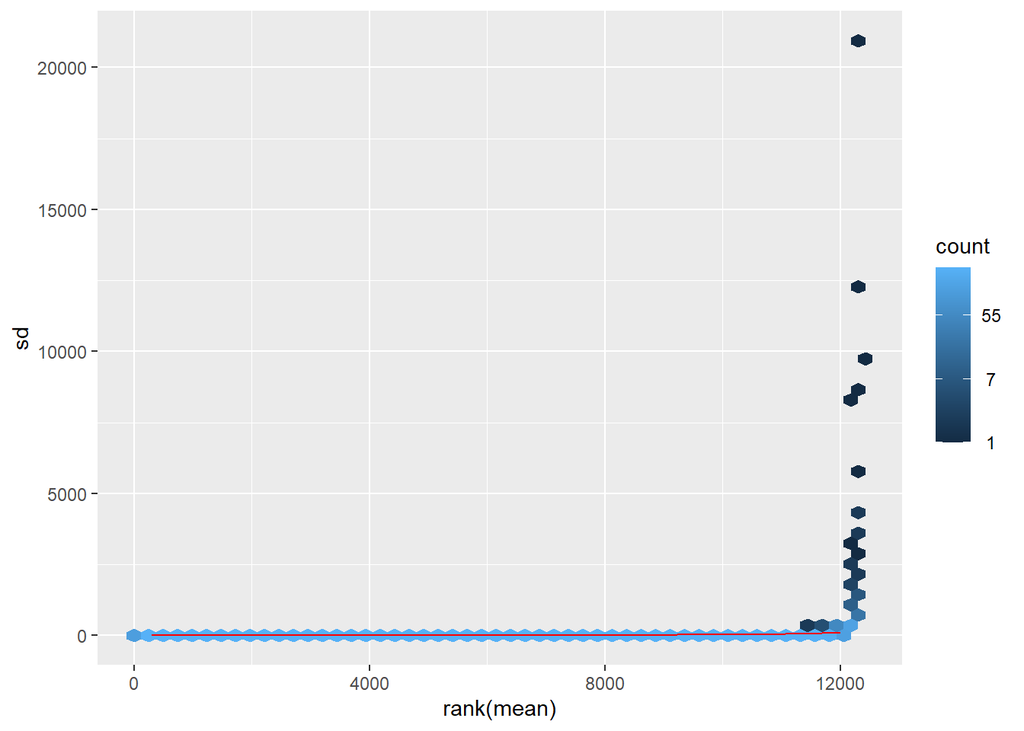

```r
# 设置图形参数以在一个设备中绘制多个图
library(vsn)

# 绘制每个图
meanSdPlot(assay(dds))
```

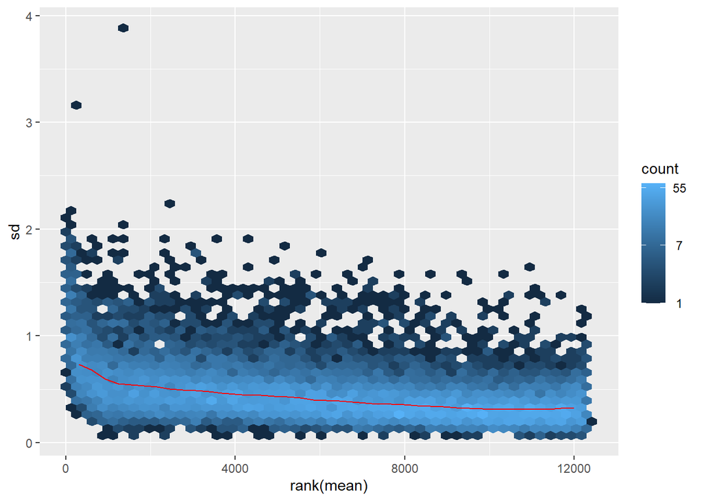

```r
meanSdPlot(assay(ntd))
```

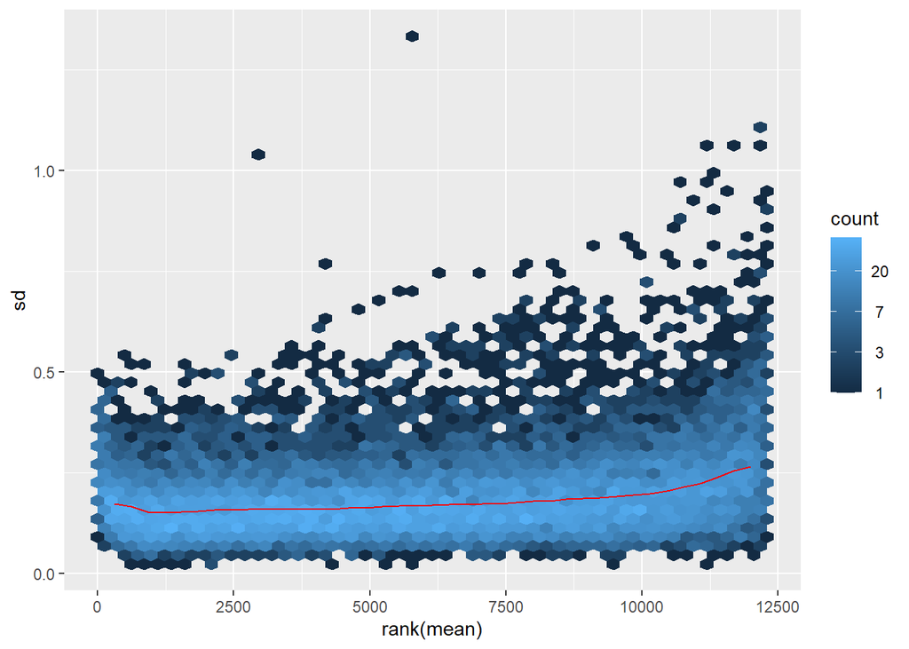

```r
meanSdPlot(assay(vsd))
```

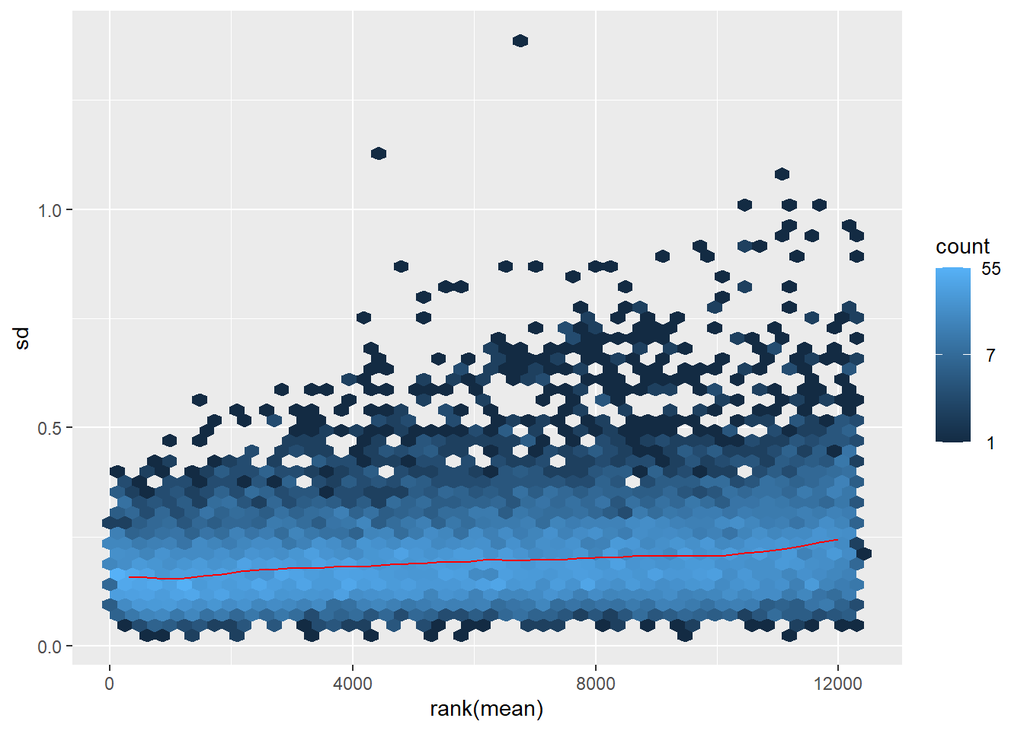

```r
meanSdPlot(assay(rld))
```

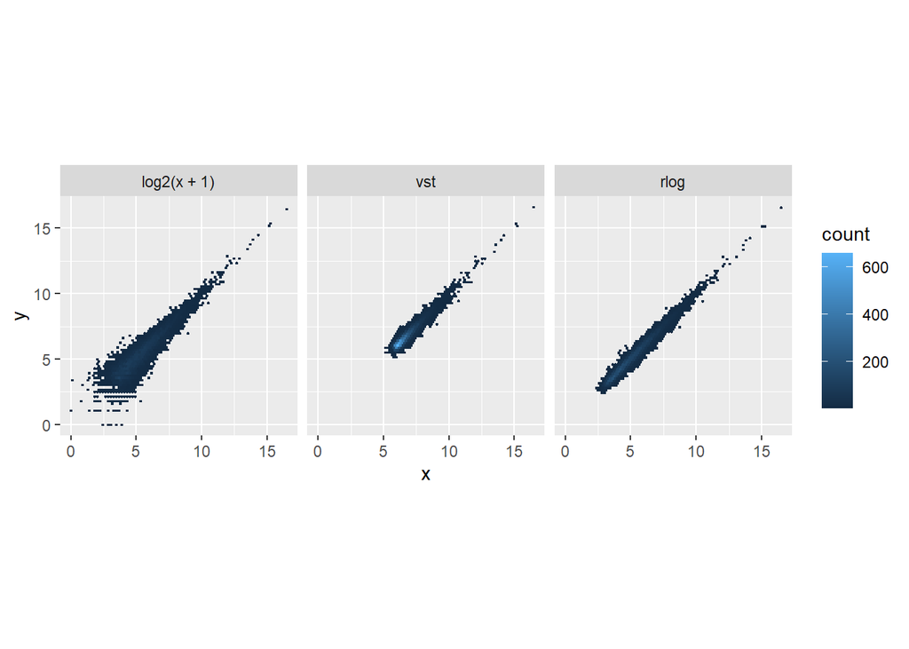

```r
library("dplyr")
library("ggplot2")
dds <- estimateSizeFactors(dds)
df <- bind_rows(
  as.data.frame(assay(ntd)[, 1:2]) %>%
    mutate(transformation = "log2(x + 1)"),
  as.data.frame(assay(vsd)[, 1:2]) %>% mutate(transformation = "vst"),
  as.data.frame(assay(rld)[, 1:2]) %>% mutate(transformation = "rlog"))

#将T5-WT1和T5-WT-2转化为x和y
colnames(df)[1:2] <- c("x", "y")

lvls <- c("log2(x + 1)", "vst", "rlog")
df$transformation <- factor(df$transformation, levels=lvls)

ggplot(df, aes(x = x, y = y)) + geom_hex(bins = 80) +
  coord_fixed() + facet_grid( . ~ transformation)
```

## 2.3 使用转换后的数据计算样本间距离

样本距离计算和查看  
注：这里计算的是样本间欧式距离：$√Σ(vect1i - vect2i)2$

```r
sampleDists <- dist(t(assay(vsd)))
sampleDists
```

```
##                 SC_Ythdc2_iKO_1 SC_Ythdc2_iKO_2 SC_Ythdc2_iKO_3 SC_Ythdc2_HT_1
## SC_Ythdc2_iKO_2        28.80667
## SC_Ythdc2_iKO_3        29.86398        22.69485
## SC_Ythdc2_HT_1         41.71595        45.10731        43.52336
## SC_Ythdc2_HT_2         41.50402        43.60272        40.24984       27.98033
## SC_Ythdc2_HT_3         37.33514        40.06567        38.86166       20.95578
##                 SC_Ythdc2_HT_2
## SC_Ythdc2_iKO_2
## SC_Ythdc2_iKO_3
## SC_Ythdc2_HT_1
## SC_Ythdc2_HT_2
## SC_Ythdc2_HT_3        25.74039
```

### 2.3.1 可视化聚类

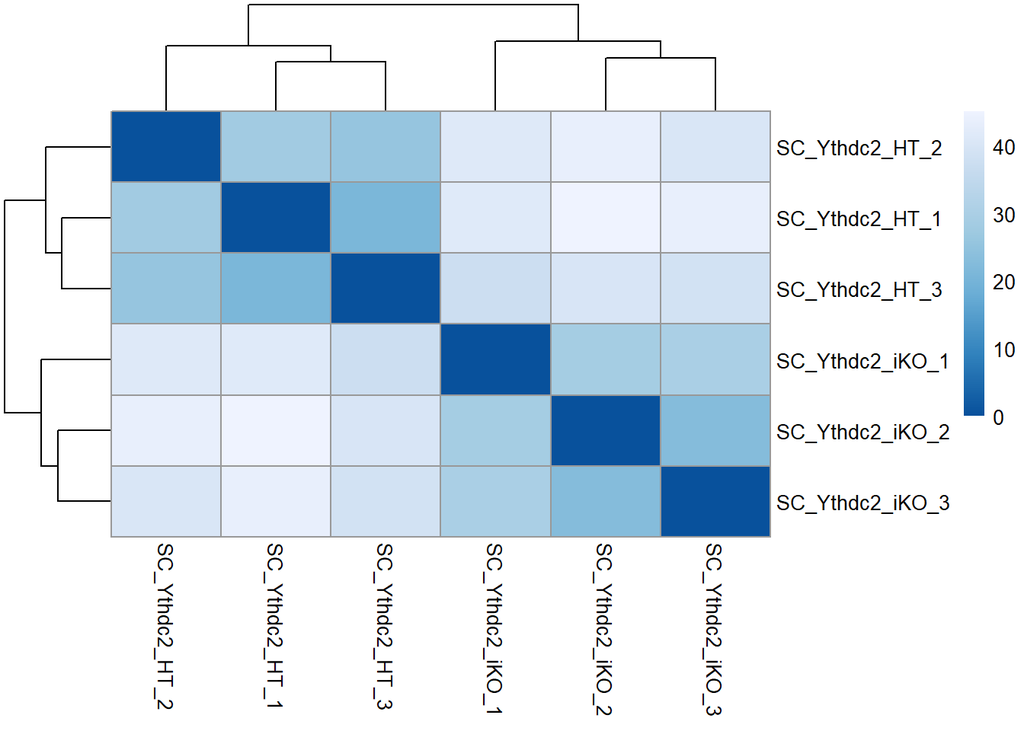

```r
library("pheatmap")
library("RColorBrewer")
sampleDistMatrix <- as.matrix( sampleDists )
colors <- colorRampPalette( rev(brewer.pal(6, "Blues")) )(255)
PDIS<-pheatmap(sampleDistMatrix,
         clustering_distance_rows = sampleDists,
         clustering_distance_cols = sampleDists,
         col = colors)
```

```r
tiff("../output/SAMPLE_HEATMAP.tiff", res = 600, width = 5200, height = 4800, compression = "lzw")
print(PDIS)
dev.off()
```

### 2.3.2 PCA图绘制

```r
pcaData <- plotPCA(vsd, intgroup = c( "condition", "sample"), returnData = TRUE)
```

```
## using ntop=500 top features by variance
```

```r
pcaData
```

```
##                        PC1        PC2                    group condition
## SC_Ythdc2_iKO_1  -8.546864  4.4319847 knockout:SC_Ythdc2_iKO_1  knockout
## SC_Ythdc2_iKO_2 -13.159031 -0.1115896 knockout:SC_Ythdc2_iKO_2  knockout
## SC_Ythdc2_iKO_3 -10.467476 -4.3208841 knockout:SC_Ythdc2_iKO_3  knockout
## SC_Ythdc2_HT_1   11.542752  1.8597040   control:SC_Ythdc2_HT_1   control
## SC_Ythdc2_HT_2   12.008937 -4.2081649   control:SC_Ythdc2_HT_2   control
## SC_Ythdc2_HT_3    8.621680  2.3489499   control:SC_Ythdc2_HT_3   control
##                          sample            name
## SC_Ythdc2_iKO_1 SC_Ythdc2_iKO_1 SC_Ythdc2_iKO_1
## SC_Ythdc2_iKO_2 SC_Ythdc2_iKO_2 SC_Ythdc2_iKO_2
## SC_Ythdc2_iKO_3 SC_Ythdc2_iKO_3 SC_Ythdc2_iKO_3
## SC_Ythdc2_HT_1   SC_Ythdc2_HT_1  SC_Ythdc2_HT_1
## SC_Ythdc2_HT_2   SC_Ythdc2_HT_2  SC_Ythdc2_HT_2
## SC_Ythdc2_HT_3   SC_Ythdc2_HT_3  SC_Ythdc2_HT_3
```

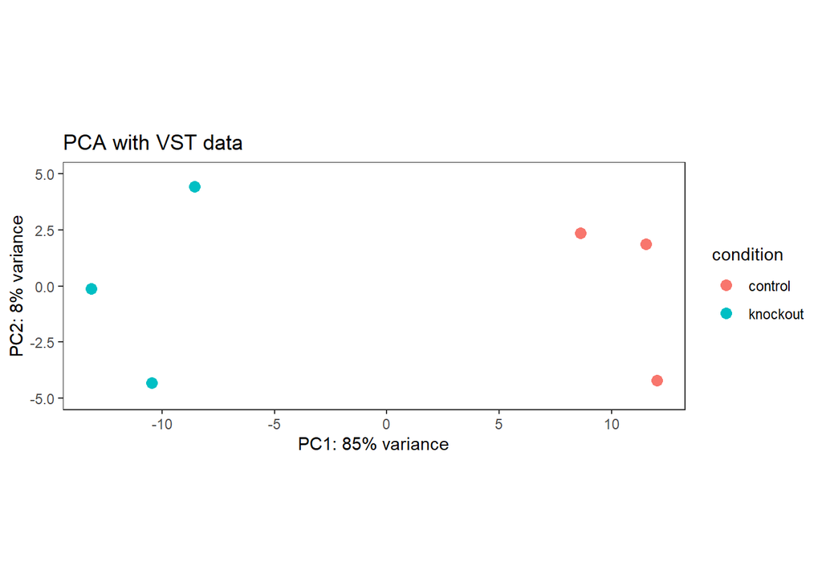

```r
percentVar <- round(100 * attr(pcaData, "percentVar"))
PCA_PLOT <- ggplot(pcaData, aes(x = PC1, y = PC2, color =condition)) +scale_y_continuous(limits = c(-5, 5))+
  geom_point(size =3) +
  xlab(paste0("PC1: ", percentVar[1], "% variance")) +
  ylab(paste0("PC2: ", percentVar[2], "% variance")) +
  coord_fixed() +
  ggtitle("PCA with VST data")+ theme_minimal() + theme_bw()+ theme(panel.grid = element_blank())+theme(legend.position = "right")
PCA_PLOT
```

```r
tiff("../output/PCA.tiff", res = 600, width = 5200, height = 4800, compression = "lzw")
print(PCA_PLOT)
dev.off()
```

# 3 进行差异分析

## 3.1 运行差异分析pipeline

使用已经建立好的DESeqDataSet对象，DESeq函数会自动进行整个分析流程并打印流程，可以使用?DESeq了解具体步骤信息。  
主要包括：估计大小因子（控制样本测序深度的差异），估计每个基因的离散值，以及拟合广义线性模型。

```r
dds <- DESeq(dds)
```

## 3.2 建立结果表

使用results函数指定比较方法，生成log2 fold changes和p values。

```r
# 生成结果表，配置比较顺序 knockout vs control
res= results(dds,contrast=c("condition","knockout","control"))
res
```

```
## log2 fold change (MLE): condition knockout vs control
## Wald test p-value: condition knockout vs control
## DataFrame with 12303 rows and 6 columns
##                      baseMean log2FoldChange     lfcSE      stat      pvalue
##                     <numeric>      <numeric> <numeric> <numeric>   <numeric>
## ENSMUSG00000025900   13.96997      -0.713427  0.513372  -1.38969   0.1646232
## ENSMUSG00000025902   16.63109      -0.904697  0.550144  -1.64447   0.1000788
## ENSMUSG00000104238   14.70052      -1.092733  0.574589  -1.90176   0.0572021
## ENSMUSG00000104328   10.27684       0.610346  0.609745   1.00099   0.3168335
## ENSMUSG00002075947    8.14221      -0.534255  0.668771  -0.79886   0.4243714
## ...                       ...            ...       ...       ...         ...
## ENSMUSG00000064363 14112.4016       0.599422  0.164726  3.638893 0.000273813
## ENSMUSG00000064367 11902.7374       0.130926  0.165821  0.789560 0.429784836
## ENSMUSG00000064368  4329.9087       0.237609  0.165197  1.438344 0.150336562
## ENSMUSG00000064370 35541.6675       0.418258  0.159075  2.629315 0.008555705
## ENSMUSG00000064372    36.3676      -0.295699  0.346064 -0.854466 0.392846886
##                          padj
##                     <numeric>
## ENSMUSG00000025900   0.422831
## ENSMUSG00000025902   0.308976
## ENSMUSG00000104238   0.214495
## ENSMUSG00000104328   0.608303
## ENSMUSG00002075947   0.700861
## ...                       ...
## ENSMUSG00000064363 0.00389447
## ENSMUSG00000064367 0.70340078
## ENSMUSG00000064368 0.40022252
## ENSMUSG00000064370 0.05596004
## ENSMUSG00000064372 0.67748742
```

## 3.3 对基因进行聚类

对基因进行聚类可以展示那些组间差别最大的基因，并且展示这些基因在样本中的分布，使用的数据是经过方差稳定性转换的数据vsd，基因是方差排在前20的基因。  
热图展示了每个基因在特定样本中偏离所有样本基因平均值的量。

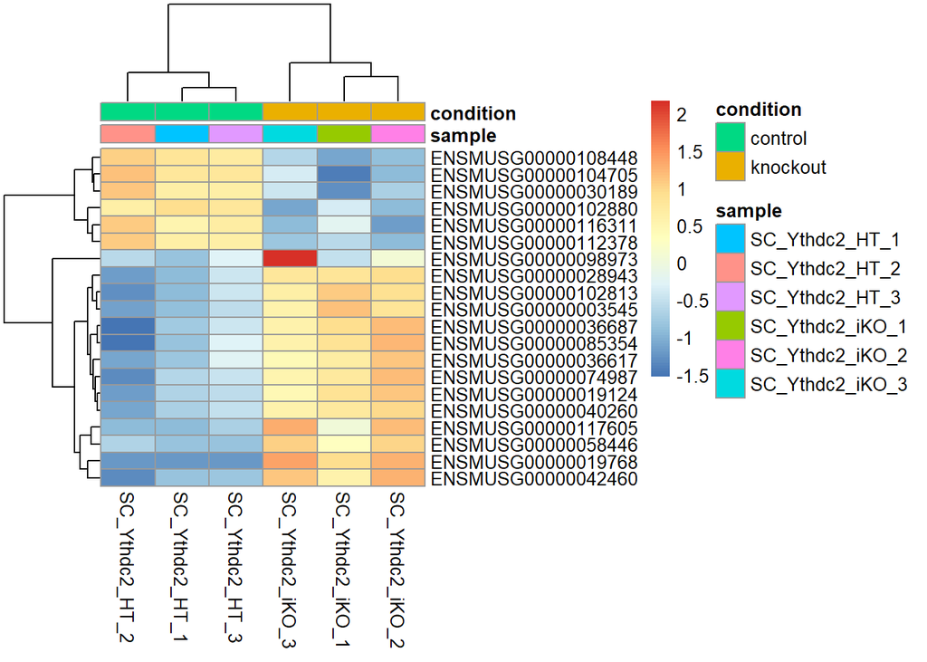

```r
library("genefilter")
#取方差前20基因
topVarGenes <- head(order(rowVars(assay(vsd)), decreasing = TRUE), 20)

#构造前20个基因的表达矩阵并减去平均表达量
mat  <- assay(vsd)[ topVarGenes, ]
mat  <- mat - rowMeans(mat)

#mat的将ensembl_gene_id转换为mgi_symbol
mat_df<- as.data.frame(mat) #将矩阵数据转化为数据框
mat_df$ensembl_gene_id = row.names(mat_df) #获取ensembl_gene_id列
anno <- as.data.frame(colData(vsd)[, c("sample","condition")])
pheatmap(mat, annotation_col = anno)
```

```r
#整合normalized count和差异分析结果
res <- merge(as.data.frame(res), as.data.frame(counts(dds, normalized = TRUE)), by = "row.names", sort = FALSE)
res
```

[output not shown]

[output cut: 23065 more lines]

# 4 注释和导出结果

```r
#进行排序
res = res[order(res$pvalue),]
```

## 4.1 转换 DESeqResults 为 data.frame() 对象，加入补充信息

```r
#获取ensembl_gene_id列
res$ensembl_gene_id = res$Row.names

#转换 DESeqResults 为 data.frame() 对象，加入补充信息
res_with_chr_info<-merge(data.frame(res),option_info,by="ensembl_gene_id")
res_with_chr_info <- res_with_chr_info[,-2]
```

## 4.2 保存全部结果

```r
write.csv(res_with_chr_info,file="../output/KO_VS_WT_DEG.csv",row.names = F)
```

# 5 保存筛选后的结果

设置筛选条件为padj < 0.05&|log2FoldChange| > 1

```r
diff_gene_deseq2 <-subset(res_with_chr_info,padj < 0.05
                          & (log2FoldChange > 1 | log2FoldChange < -1))
```

```r
dim(diff_gene_deseq2)
```

```
## [1] 1197   16
```

```r
write.csv(diff_gene_deseq2,file= "../output/KO_VS_WT_DEG_up_and_down_FC1.csv",row.names = F)
```

```r
diff_gene_deseq2_UP <-subset(res_with_chr_info,padj < 0.05
                          & log2FoldChange > 1 )
write.csv(diff_gene_deseq2_UP,file= "../output/KO_VS_WT_DEG_up_FC1.csv",row.names = F)

diff_gene_deseq2_DOWN <-subset(res_with_chr_info,padj < 0.05
                          &  log2FoldChange < -1)
write.csv(diff_gene_deseq2_DOWN,file= "../output/KO_VS_WT_DEG_down_FC1.csv",row.names = F)
```

# 6 保存筛选后的结果

设置筛选条件为padj < 0.05&|log2FoldChange| > 0.6

```r
diff_gene_deseq2 <-subset(res_with_chr_info,padj < 0.05
                          & (log2FoldChange > 0.6 | log2FoldChange < -0.6))
```

```r
dim(diff_gene_deseq2)
```

```
## [1] 1748   16
```

```r
write.csv(diff_gene_deseq2,file= "../output/KO_VS_WT_DEG_up_and_down_FC0.6.csv",row.names = F)
```

```r
diff_gene_deseq2_UP <-subset(res_with_chr_info,padj < 0.05
                          & log2FoldChange > 0.6 )
write.csv(diff_gene_deseq2_UP,file= "../output/KO_VS_WT_DEG_up_FC0.6.csv",row.names = F)

diff_gene_deseq2_DOWN <-subset(res_with_chr_info,padj < 0.05
                          &  log2FoldChange < -0.6)
write.csv(diff_gene_deseq2_DOWN,file= "../output/KO_VS_WT_DEG_down_FC0.6.csv",row.names = F)
```